# Praca domowa 2

Julian Mierzejewski

## Dane

Dane wykorzystane w Pracy domowej 2 dotyczą wyników egzaminów z 3 umiejętności: czytania, pisania i operacji matematycznych. Dodatkowo dostępne są podstawowe informacje o studentach i ich rodzicach. Opis wszystkich kolumn znajduje się również w pliku `README.md`.

| Zmienna | Opis |
| --- | --- |
| **gender** | płeć |
| **race.ethnicity** | pochodzenie etniczne |
| **parental.level.of.education** | wykształcenie rodziców |
| **lunch** | jaki obiad jedli uczniowie w dniu egzaminu |
| **test.preparation.course** | czy uczeń odbył kurs przygotowujący |
| **math.score** | wynik egzaminu z matematyki |
| **reading.score** | wynik egzaminu z czytania |
| **writing.score** | wynik egzaminu z pisania |

## Zadanie 1

Jak wyglądają rozkłady wyników uczniów z trzech przedmiotów (matematyka, czytanie, pisanie)?

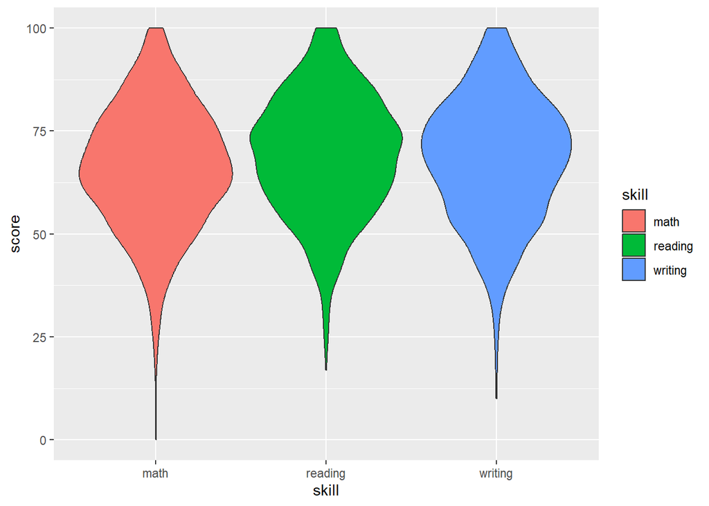

```r
# Tu umieść kod do wygenerowania odpowiedzi do zadania.

df %>%
  select(math, writing, reading) %>%
  pivot_longer(everything(),names_to = "skill", values_to = "score") %>%

  ggplot(aes(x = skill, y = score, fill = skill)) +
    geom_violin()
```

**Komentarz: wyniki są mniej więcej równo rozłożone dla każdego typu testu**

## Zadanie 2

Czy istnieje zauważalna różnica w wynikach między uczniami i uczennicami?

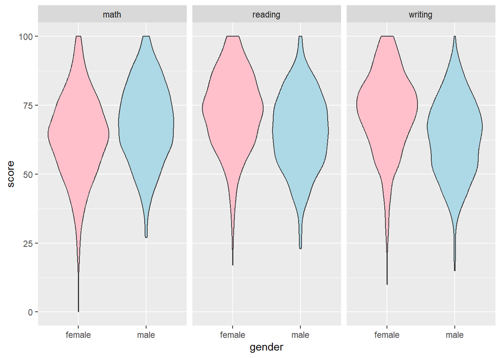

```r
df %>%
  select(gender, math, reading, writing) %>%
  pivot_longer(cols = c(math, reading, writing),
  names_to = "skill", values_to = "score") %>%


ggplot( aes(x = gender, y = score, fill = gender)) +
  geom_violin() +
  facet_wrap( ~ skill, nrow =1)+
  scale_fill_manual(values = c(female = "pink", male = "lightblue"))+
  theme(legend.position = "none")
```

**Komentarz: uczniowie zdobywają troche lepsze wyniki w testach z matematyki natomiast ucznnice mają lepsze wyniki z pisania i czytania**

## Zadanie 3

Czy uczniowie, którzy ukończyli kurs przygotowawczy, osiągają lepsze wyniki niż pozostali?

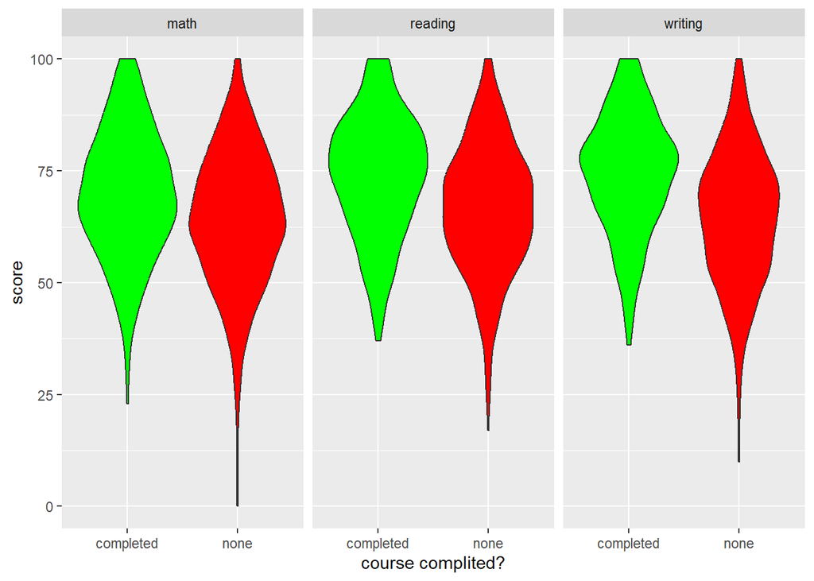

```r
df %>%
  select(test.preparation.course, math, reading, writing) %>%
  pivot_longer(cols = c(math, reading, writing),
  names_to = "skill", values_to = "score") %>%


ggplot( aes(x = test.preparation.course, y = score, fill = test.preparation.course)) +
  geom_violin() +
  facet_wrap( ~ skill, nrow =1)+
  scale_fill_manual(values = c(none = "red", completed = "green"))+
  theme(legend.position = "none")+
  labs(x = "course complited?")
```

**Komentarz:uczniowie którzy ukończyli kurs przygotowawczy zdobywają zauważalnie lepsze wyniki w każdym z testów**

## Zadanie 4

Jaki jest związek między poziomem wykształcenia rodziców a średnimi wynikami uczniów?

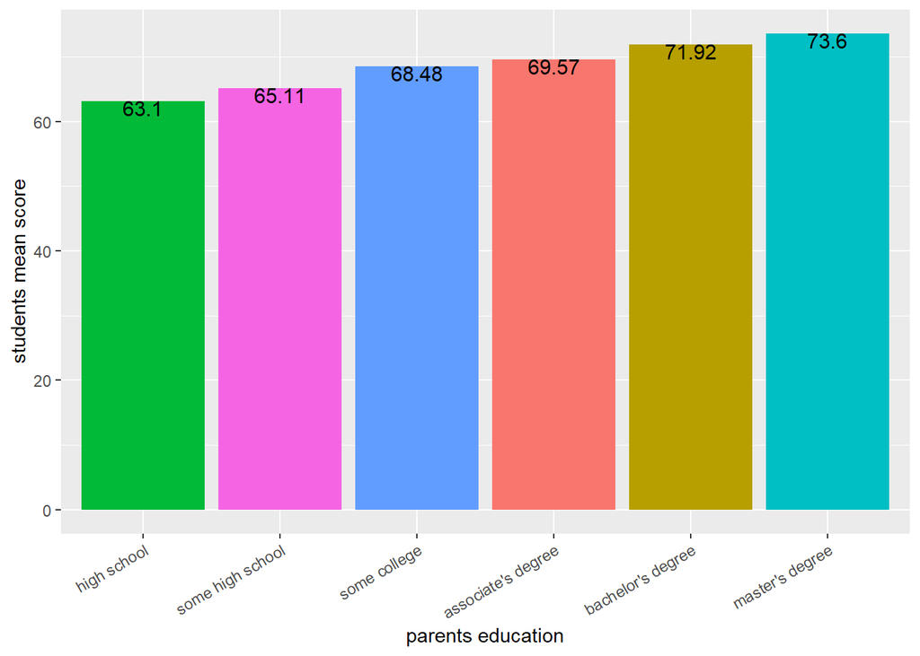

```r
df %>%
  select(parental.level.of.education, math, reading, writing) %>%
  pivot_longer(c(math, reading, writing),names_to = "skill", values_to = "score") %>%
  group_by(parental.level.of.education) %>%
  summarise(mean_score = mean(score, na.rm = TRUE)) %>%
  arrange(mean_score) %>%

ggplot( aes(y = mean_score, x = reorder(parental.level.of.education, mean_score), fill = parental.level.of.education)) +
  geom_col() +
  geom_text(aes(label = round(mean_score, digits = 2)), size = 4, nudge_y = -1.) +
  theme(legend.position = "none")+
  labs(x = "parents education", y = "students mean score")+
  theme(axis.text.x = element_text(angle = 30, hjust = 1))
```

## Zadanie 5

Czy płeć i wykształcenie rodzica wpływa na wynik z matematyki?

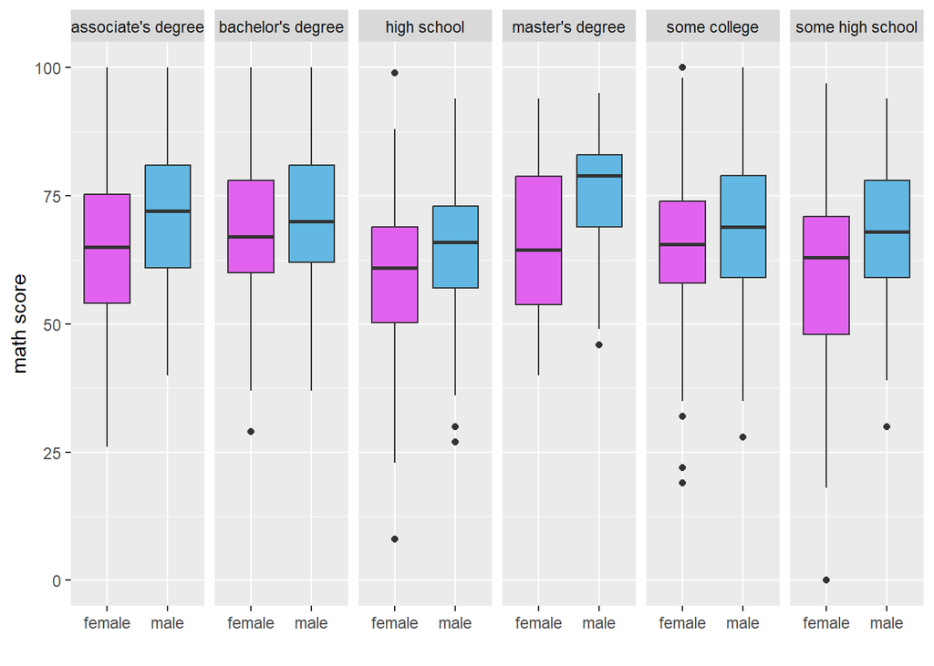

```r
df %>%
  select(gender, parental.level.of.education, math) %>%
ggplot( aes(x = gender, y = math, fill = gender)) +
  geom_boxplot() +
  facet_wrap( ~ parental.level.of.education, nrow =1)+
  scale_fill_manual(values = c(male = "#62B8E3", female = "#E262F0"))+
  theme(legend.position = "none")+
  labs(x = " ", y = "math score")
```

## Zadanie 6

Czy istnieje zależność między wynikami z matematyki a wynikami z czytania lub pisania?

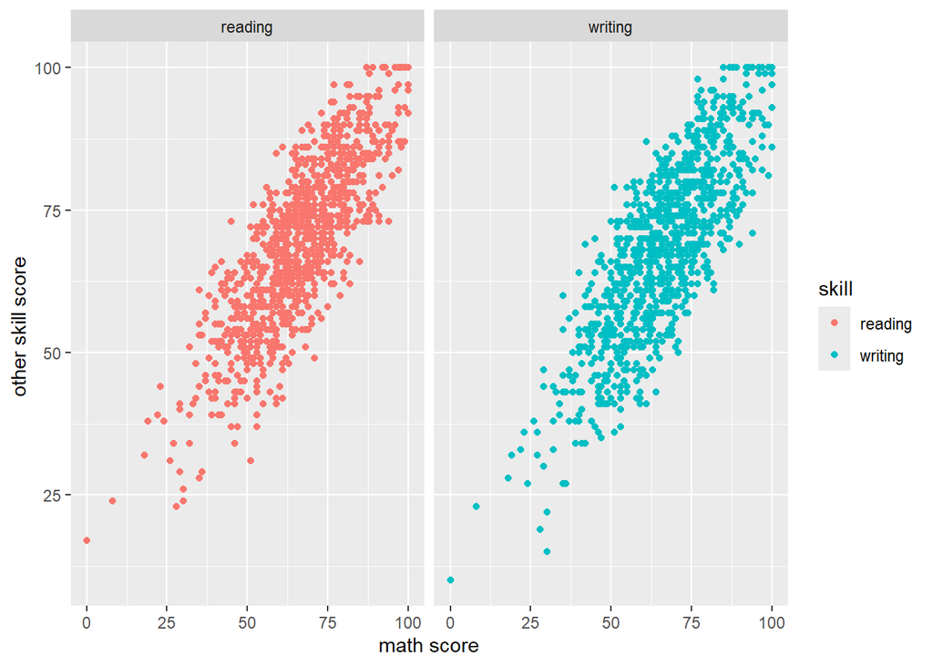

```r
df %>%
  select(math, writing, reading) %>%
  pivot_longer(c(reading,writing),names_to = "skill", values_to = "score") %>%
  ggplot( aes(x = math, y = score, color = skill)) +
    geom_point()+
    facet_wrap( ~ skill, nrow =1)+
    labs(y = "other skill score ", x = "math score")
```

**Komentarz: tak istnieje taka zależność, uczniowe którzy mają dobre wyniki z matematyki mają również wysokie wyniki z przynajmniej jednego innego przedmiotu i dowrotnie uczniowie którzy mają dobre wyniki z czytania i/lub pisania mają dobry wynik z matematyki**